# ANÁLISE DE VINHOS TINTOS por ANDRÉ PEREIRA

O objetivo deste estudo é descobrir quais atributos mais contribuem para a qualidade do vinho.Vamos estudar as relações entre os atributos visando saber quais combinações de valores geram vinhos com qualidades superiores.

# Seção de Gráficos Univariados

Esse arquivo contém 1599 observações com 13 variáveis. Vamos primeiro ver os valores máximos, mínimos, médios e medianos para cada atributo.

## Nomes e Sumário

```
##  [1] "X"                    "fixed.acidity"        "volatile.acidity"
##  [4] "citric.acid"          "residual.sugar"       "chlorides"
##  [7] "free.sulfur.dioxide"  "total.sulfur.dioxide" "density"
## [10] "pH"                   "sulphates"            "alcohol"
## [13] "quality"
```

```
##        X          fixed.acidity   volatile.acidity  citric.acid
##  Min.   :   1.0   Min.   : 4.60   Min.   :0.1200   Min.   :0.000
##  1st Qu.: 400.5   1st Qu.: 7.10   1st Qu.:0.3900   1st Qu.:0.090
##  Median : 800.0   Median : 7.90   Median :0.5200   Median :0.260
##  Mean   : 800.0   Mean   : 8.32   Mean   :0.5278   Mean   :0.271
##  3rd Qu.:1199.5   3rd Qu.: 9.20   3rd Qu.:0.6400   3rd Qu.:0.420
##  Max.   :1599.0   Max.   :15.90   Max.   :1.5800   Max.   :1.000
##  residual.sugar     chlorides       free.sulfur.dioxide
##  Min.   : 0.900   Min.   :0.01200   Min.   : 1.00
##  1st Qu.: 1.900   1st Qu.:0.07000   1st Qu.: 7.00
##  Median : 2.200   Median :0.07900   Median :14.00
##  Mean   : 2.539   Mean   :0.08747   Mean   :15.87
##  3rd Qu.: 2.600   3rd Qu.:0.09000   3rd Qu.:21.00
##  Max.   :15.500   Max.   :0.61100   Max.   :72.00
##  total.sulfur.dioxide    density             pH          sulphates
##  Min.   :  6.00       Min.   :0.9901   Min.   :2.740   Min.   :0.3300
##  1st Qu.: 22.00       1st Qu.:0.9956   1st Qu.:3.210   1st Qu.:0.5500
##  Median : 38.00       Median :0.9968   Median :3.310   Median :0.6200
##  Mean   : 46.47       Mean   :0.9967   Mean   :3.311   Mean   :0.6581
##  3rd Qu.: 62.00       3rd Qu.:0.9978   3rd Qu.:3.400   3rd Qu.:0.7300
##  Max.   :289.00       Max.   :1.0037   Max.   :4.010   Max.   :2.0000
##     alcohol         quality
##  Min.   : 8.40   Min.   :3.000
##  1st Qu.: 9.50   1st Qu.:5.000
##  Median :10.20   Median :6.000
##  Mean   :10.42   Mean   :5.636
##  3rd Qu.:11.10   3rd Qu.:6.000
##  Max.   :14.90   Max.   :8.000
```

```
##    Min. 1st Qu.  Median    Mean 3rd Qu.    Max.
##   3.000   5.000   6.000   5.636   6.000   8.000
```

## Distribuição do atributo Qualidade

Agora vamos ver qual a distribuição de cada nota.

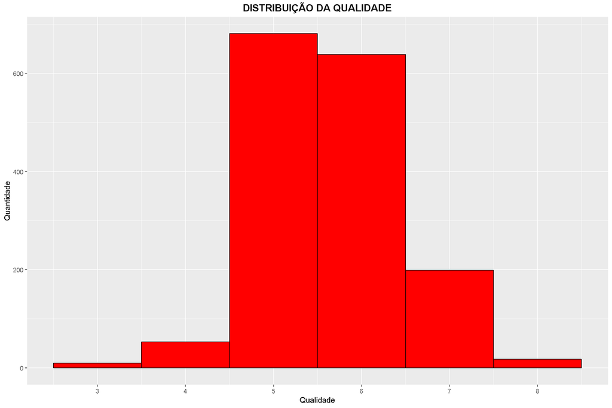

Podemos ver que a maior parte das notas se concentra ente 5 e 6.

## Seção de Gráficos Univariaveis

Nesta seção iremos trabalhar com gráficos com apenas uma variável isolada e tentar descobrir alguma relação com a qualidade.

## Distribuição dos outros elementos químicos

Vamos começar fazendo uma distribuição de cada atribuito em relação a quantidade, para ter uma noção do tipo de distruição(Normal, cauda longa, etc.)

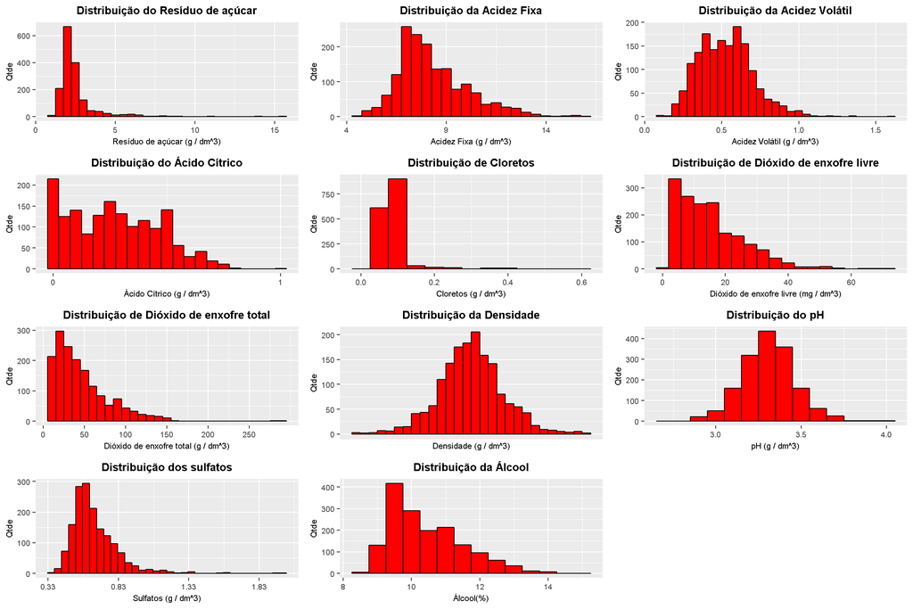

## Calculando correlações

Como nosso objetivo é saber atráves desses dados é saber qual elemento químico mais influencia na qualidade do vinho, vamos calcular correlações entre os atributos, para ver o que podemos tirar disso.

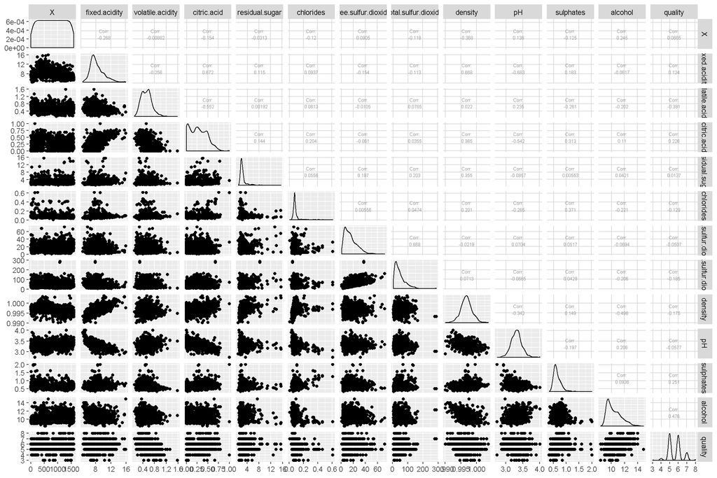

## Analisando as correlações

```
##
##  Pearson's product-moment correlation
##
## data:  wn$quality and wn$fixed.acidity
## t = 4.996, df = 1597, p-value = 6.496e-07
## alternative hypothesis: true correlation is not equal to 0
## 95 percent confidence interval:
##  0.07548957 0.17202667
## sample estimates:
##       cor
## 0.1240516
```

```
##
##  Pearson's product-moment correlation
##
## data:  wn$quality and wn$volatile.acidity
## t = -16.954, df = 1597, p-value < 2.2e-16
## alternative hypothesis: true correlation is not equal to 0
## 95 percent confidence interval:
##  -0.4313210 -0.3482032
## sample estimates:
##        cor
## -0.3905578
```

```
##
##  Pearson's product-moment correlation
##
## data:  wn$quality and wn$citric.acid
## t = 9.2875, df = 1597, p-value < 2.2e-16
## alternative hypothesis: true correlation is not equal to 0
## 95 percent confidence interval:
##  0.1793415 0.2723711
## sample estimates:
##       cor
## 0.2263725
```

```
##
##  Pearson's product-moment correlation
##
## data:  wn$quality and wn$residual.sugar
## t = 0.5488, df = 1597, p-value = 0.5832
## alternative hypothesis: true correlation is not equal to 0
## 95 percent confidence interval:
##  -0.03531327  0.06271056
## sample estimates:
##        cor
## 0.01373164
```

```
##
##  Pearson's product-moment correlation
##
## data:  wn$quality and wn$chlorides
## t = -5.1948, df = 1597, p-value = 2.313e-07
## alternative hypothesis: true correlation is not equal to 0
## 95 percent confidence interval:
##  -0.17681041 -0.08039344
## sample estimates:
##        cor
## -0.1289066
```

```
##
##  Pearson's product-moment correlation
##
## data:  wn$quality and wn$free.sulfur.dioxide
## t = -2.0269, df = 1597, p-value = 0.04283
## alternative hypothesis: true correlation is not equal to 0
## 95 percent confidence interval:
##  -0.099430290 -0.001638987
## sample estimates:
##         cor
## -0.05065606
```

```
##
##  Pearson's product-moment correlation
##
## data:  wn$quality and wn$total.sulfur.dioxide
## t = -7.5271, df = 1597, p-value = 8.622e-14
## alternative hypothesis: true correlation is not equal to 0
## 95 percent confidence interval:
##  -0.2320162 -0.1373252
## sample estimates:
##        cor
## -0.1851003
```

```
##
##  Pearson's product-moment correlation
##
## data:  wn$quality and wn$density
## t = -7.0997, df = 1597, p-value = 1.875e-12
## alternative hypothesis: true correlation is not equal to 0
## 95 percent confidence interval:
##  -0.2220365 -0.1269870
## sample estimates:
##        cor
## -0.1749192
```

```
##
##  Pearson's product-moment correlation
##
## data:  wn$quality and wn$pH
## t = -2.3109, df = 1597, p-value = 0.02096
## alternative hypothesis: true correlation is not equal to 0
## 95 percent confidence interval:
##  -0.106451268 -0.008734972
## sample estimates:
##         cor
## -0.05773139
```

```
##
##  Pearson's product-moment correlation
##
## data:  wn$quality and wn$sulphates
## t = 10.38, df = 1597, p-value < 2.2e-16
## alternative hypothesis: true correlation is not equal to 0
## 95 percent confidence interval:
##  0.2049011 0.2967610
## sample estimates:
##       cor
## 0.2513971
```

```
##
##  Pearson's product-moment correlation
##
## data:  wn$quality and wn$alcohol
## t = 21.639, df = 1597, p-value < 2.2e-16
## alternative hypothesis: true correlation is not equal to 0
## 95 percent confidence interval:
##  0.4373540 0.5132081
## sample estimates:
##       cor
## 0.4761663
```

Com esses valores temos um bom ponto de partida para nossa análise, podemos ver que as maiores correlações com o atributo qualidade são:

Alcool : 0.476 Acidez Volátil : -0.390 Sulfato : 0.251

Apartir de agora vamos focar nesses 3 atributos, tentando desvendar suas relações com a qualidade do vinho

## Outliers

Antes de iniciar novas análises, vamos remover os outliers desses 3 atributos, visando retirar os pontos que podem atrapalhar as análises.

Vamos novamente sumarizar para ver a diferença de valores com a primeira vez que utilizamos o sumary(). ***Rode apenas uma vez!

```
##        X          fixed.acidity    volatile.acidity  citric.acid
##  Min.   :   1.0   Min.   : 4.600   Min.   :0.1200   Min.   :0.0000
##  1st Qu.: 414.2   1st Qu.: 7.100   1st Qu.:0.3900   1st Qu.:0.0900
##  Median : 817.5   Median : 7.900   Median :0.5200   Median :0.2500
##  Mean   : 810.7   Mean   : 8.327   Mean   :0.5225   Mean   :0.2664
##  3rd Qu.:1203.8   3rd Qu.: 9.275   3rd Qu.:0.6350   3rd Qu.:0.4200
##  Max.   :1599.0   Max.   :15.600   Max.   :1.0000   Max.   :0.7900
##  residual.sugar     chlorides       free.sulfur.dioxide
##  Min.   : 0.900   Min.   :0.01200   Min.   : 1.00
##  1st Qu.: 1.900   1st Qu.:0.07000   1st Qu.: 7.00
##  Median : 2.200   Median :0.07900   Median :13.00
##  Mean   : 2.549   Mean   :0.08314   Mean   :15.83
##  3rd Qu.: 2.600   3rd Qu.:0.08900   3rd Qu.:21.00
##  Max.   :15.500   Max.   :0.38700   Max.   :72.00
##  total.sulfur.dioxide    density             pH          sulphates
##  Min.   :  6.00       Min.   :0.9901   Min.   :2.860   Min.   :0.3300
##  1st Qu.: 22.00       1st Qu.:0.9956   1st Qu.:3.212   1st Qu.:0.5500
##  Median : 37.00       Median :0.9967   Median :3.310   Median :0.6200
##  Mean   : 45.63       Mean   :0.9968   Mean   :3.315   Mean   :0.6367
##  3rd Qu.: 60.00       3rd Qu.:0.9979   3rd Qu.:3.400   3rd Qu.:0.7100
##  Max.   :289.00       Max.   :1.0037   Max.   :4.010   Max.   :0.9900
##     alcohol         quality
##  Min.   : 8.40   Min.   :3.000
##  1st Qu.: 9.50   1st Qu.:5.000
##  Median :10.20   Median :6.000
##  Mean   :10.41   Mean   :5.644
##  3rd Qu.:11.10   3rd Qu.:6.000
##  Max.   :13.50   Max.   :8.000
```

# Análise Univariada

### Qual é a estrutura do conjunto de dados?

Distribuição Normal:Densidade, pH, Acidez volátil, Acidez Fixa.

Cauda longa: Resíduo de açúcar, Cloretos,

### Quais são os principais atributos de interesse deste conjunto de dados?

De acordo com os valores de correlação que foram encontrados, o atributo álcool é o que mais influencia a qualidade do vinho.

### Quais outros atributos você acha que podem lhe auxiliar na investigação destes atributos de interesse?

Acho que a acidez volátil, ácool e sulfatos podem ter grande influência, devido a alto valor de correlação, e esses serão os atributos que irei focar.

### Você criou novas variáveis a partir dos atributos existentes no conjunto de dados?

Criei a variável para tirar os outliers do álcool, acidez volátil e sulfatos.

### Dos atributos investigados, distribuições incomuns foram encontradas? Você aplicou operações nos dados para limpá-los, ajustá-los ou mudar a forma dos dados? Se sim, por que?

O resíduo e açucar e Cloretos apresentaram distribuição de cauda longa.

# Seção de Gráficos Bivariados

Agora iremos trabalhar com gráficos que trabalham com duas variáveis, queremos aqui ver se encontramos relação fortes entre a qualidade e os 3 atributos que escolhemos.

Vamos começar com um gráfico de pontos, olhando a distribuição entre o atributo e a qualidade, e vamos inserir uma linha linear.

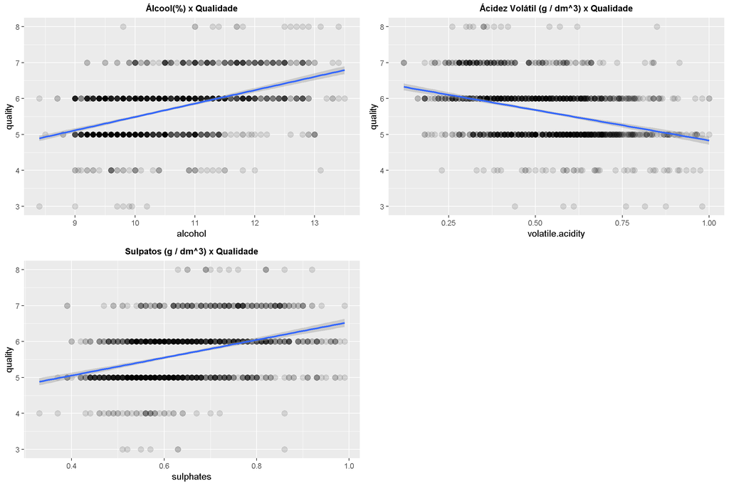

Apesar de ser possível vermos algumas relações, vamos tetnar trabalhar com boxplots, que devem nos dar uma melhor visualização.

## Qualidade categorizado

Vamos criar uma nova variável para separar por categorias, para poder criar boxplots.

```
## [1] 5 5 5 6 5 5
## Levels: 3 4 5 6 7 8
```

## Boxplots com os principais atributos

Os três principais atributos, vamos criar box plots relacionando as notas com os valores de cada atributo, para vermos se encontramos algum padão com as alterações dos valores.

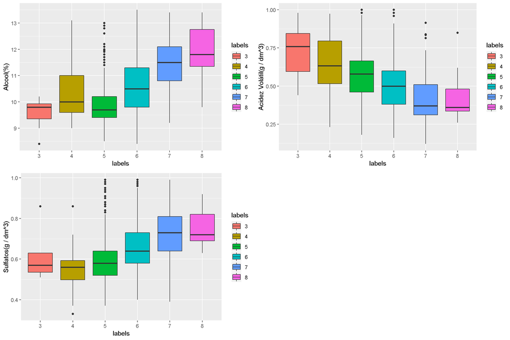

COm esses gráficos, podemos ver um certo padrão, principalmente na acidez volátil, onde a qualidade é inversamente proporcional ao valor desse atributo.

## Driagramas de desidade.

Vamos tentar também ver esses dados pela densidade, relaionando aqualidade com o atributo. Vamos comerçar fazendo com o atributo “Alcool”.

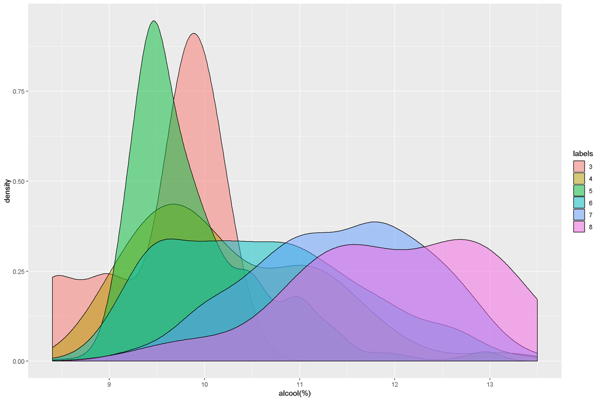

## Criação de categorias para as notas

No primeiro plot, dada a quantidade alta de notas o gráfica se torna confuso, e ficaria mais visível as relações se agrupassemos as notas em menos categorias. Para isso vamos dividir as 6 notas em apenas 3 notas, sendo elas “Baixa”, “Média”, “Alta”.

## Diagras de densidade com menos categorias para qualidade

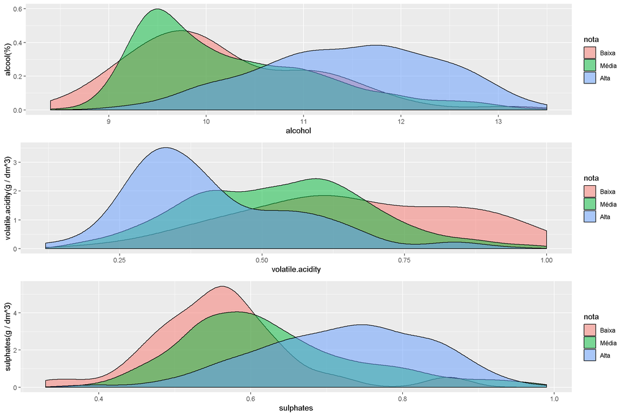

Com esses três ultimos gráficos podemos ter uma norção muito boa onde se concetram as notas mais altas apra cada atributo.

# Análise Bivariada

### Discuta sobre alguns dos relacionamentos observados nesta parte da investigação. Como os atributos de interesse variaram no conjunto de dados?

Podemos ver que como imaginado, os 3 atributos deram uma noção muito boa de onde se concetram as notas mais altas, no álcool as notas mais altas estão com o valor 12, enquanto na acidez volátil estão no valor .3, e já com os sulfatos estão próximos ao .78.

### Você observou algum relacionamento interessante entre os outros atributos (os que não são de interesse)?

Não.

### Qual foi o relacionamento mais forte encontrado?

O relaciomaneto mais forte foi com o Alcool.

# Seção de Gráficos Multivariados

Nestes 2 primeiros gráficos vamos verificar a relação do álcool, que já vimos ser o principal atributo relacionado a qualidade, mas adicionando uma nova variável a cada gráfico.

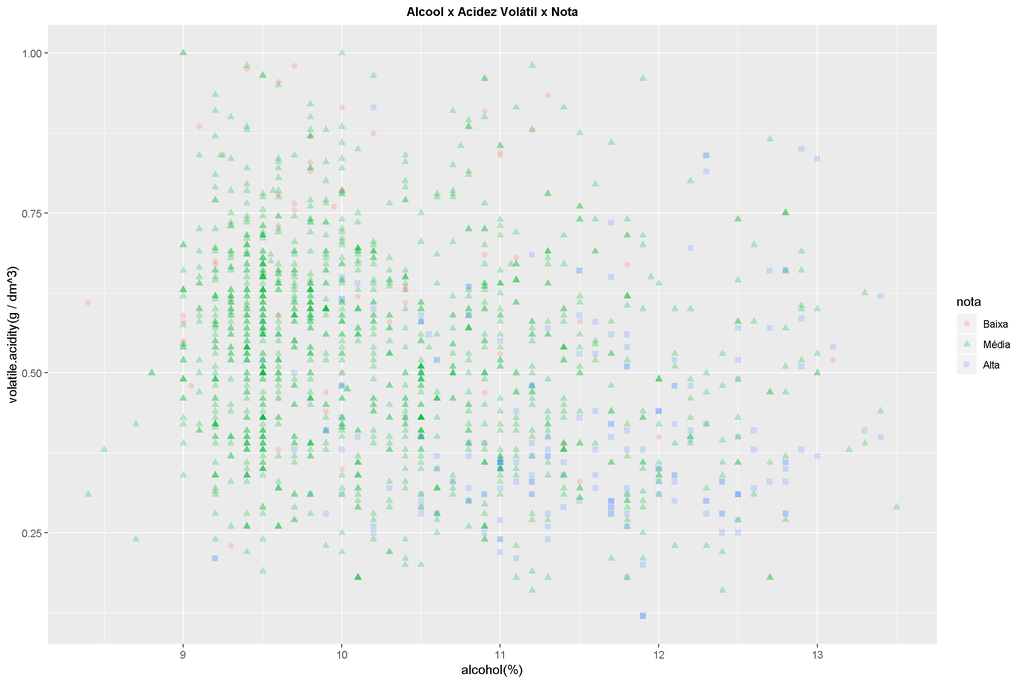

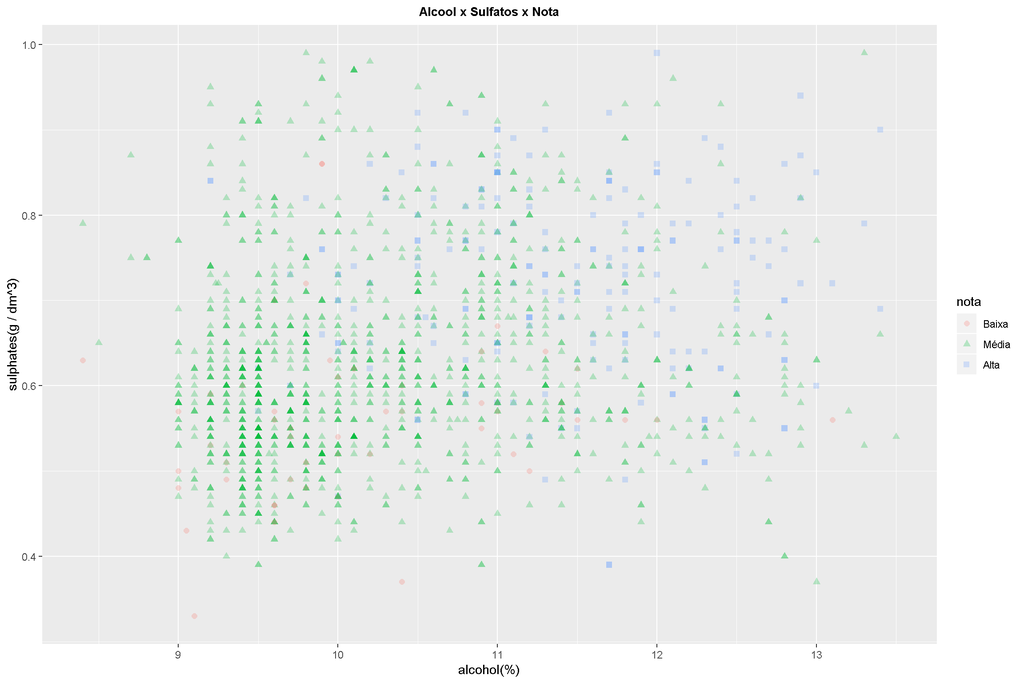

Com essas relações podemos levantar novas suposições, é visível que no primeiro gráfico as notas mais altas se concentram em valores menores de acidez volátil e valores eledos de álcool, já no segundo, a concentração de sulfato com as notas altas ficou entre .6 e .8.

Agora podemos realizar esses mesmos estudos, mas utilizando as duas variáveis como princupal, vamos começar pela acidez volátil

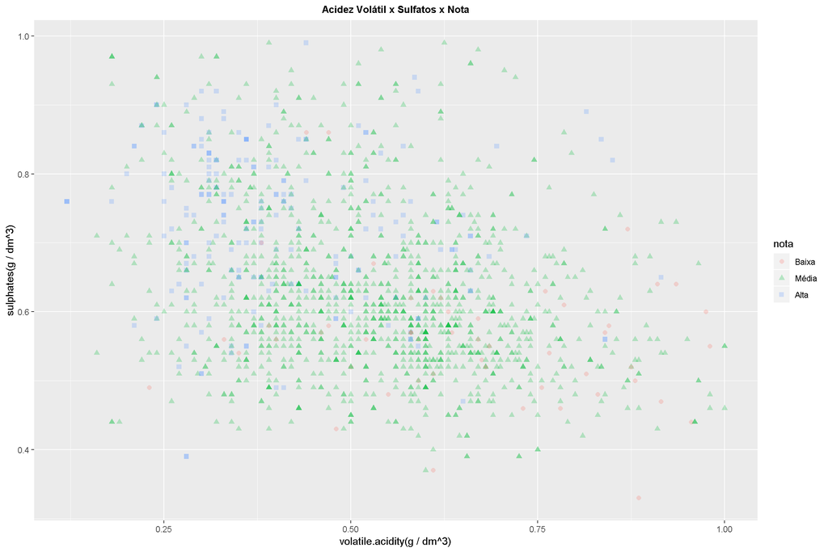

# Anáise Multivariada

### Discuta sobre os relacionamentos observados nesta parte da investigação. Quais atributos que fortaleceram os demais na observação das variáveis de interesse?

Gráfico 1: Esse foi o gráfico que menos demonstrou relacionamento entre as variáveis estudadas,elas não estão visivelmente separadas, no entando podemos ver que os pontos azuis, referentes a qualidade mais alta, está concentrada no canto inefrior direto, onde os valores de álcool são altos e os de acidez volático ssão mais baixos.

Gráfico 2: Esse gráfico também está bastante difuso, é possível ver uma certa prevalência com valores altos de álcool e valores altos de sulfato.

Gráfico 3: Esse é o gráfico com a melhor visualização das notas, onde os valores dados como “Alto” estão concetrados entre 0.25 e 0,50 para a acidez volátil, e entre 0.6 e 0.8 para o Sulfato.

### Interações surpreendentes e/ou interessantes foram encontradas entre os atributos?

A interação entre a acidez voláti e o sulfato se demonstrou com um resultado interessante.

# Gráficos Finais e Sumário

### Primeiro Gráfico

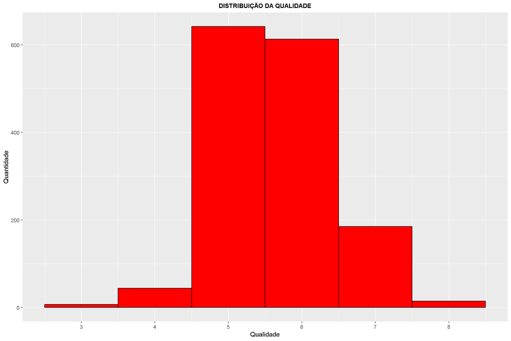

### Descrição do Primeiro Gráfico

O primeiro gráfico se limita a contar quantos vinhos foram classificados com cada nota, nos dando uma noção de onde se concentram a maior parte das notas.

### Segundo Gráfico

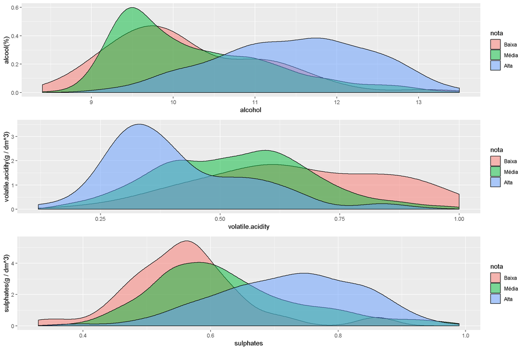

### Descrição do Segundo Gráfico

NEste gráfico estudamos as desidades referentes a quantidade de cada atributo, em comparação com a nota que lhe foi atribuída, onde é possível ver onde existe concentração das maiores notas.

### Terceiro Gráfico

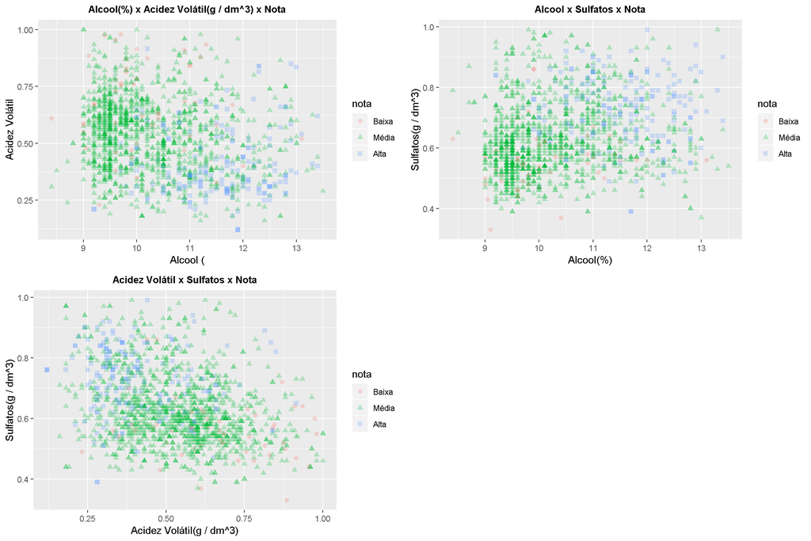

### Descrição do Terceiro Gráfico

Nestes gráficos buscamos visualizar uma correção entre dois atributos, para buscar onde os pontos referentes as maireos notas vão estar com maior concentração;

# Reflexão

É interessante ver como mesmo em um estudo em que meu conhecimento prévio era quase nulo, foi possível trabalhar nesses dados e extrair informações valiosas. O vinho é uma bebida complexa, com diversas características que podem afetar a preferência do consumidor. A aparência, corpo, aroma, são outros pontos que podem influenciar na qualidade e aceitação do produto. Então busquei aqui procurar onde se concentravam as maiores notas, relacionando os atributos e fazendo hipóteses do que daria ou não uma melhor visualização. Tive algumas dificuldades em desenvolver o estudo por não saber qual caminho trilhar, quais hipóteses iniciais usar e quais gráficos dariam uma melhor visualização, mas isso foi sendo revisto para chegar num nível adequado. Com a linguagem R, me vi com dificuldades para personalizar o gráfico da maneira que imagiei, sem que ficasse com letras muito grades ou pequenas, ou informações dobrepostas e bagunçadas. Queria que ficasse o máximo visível e simples possível. Para o futuro seria interessante estudar a qualidade de outros tipos de alimentos ou bebidas, como cervejas por exemplo.